# Lab_13

Fantastic Four

# How can CU Improve?

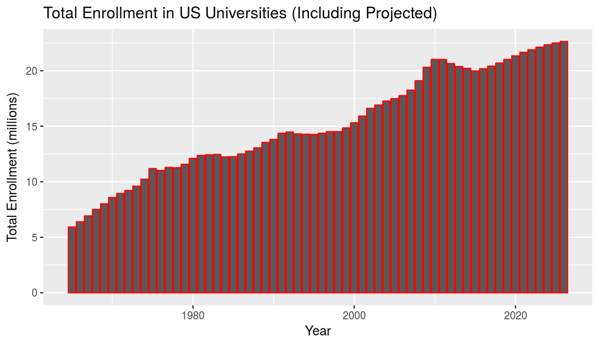

```r
#for overall question
ggplot(collegeEnroll, aes(y=Public+Private, x=year)) +
    geom_bar( stat="identity",color="red") +
    xlab("Year") +
    ylab("Total Enrollment (millions)") +
    ggtitle("Total Enrollment in US Universities (Including Projected)")
```

# Subquestions

## How has food consumption changed in the last forty years? (Scott)

Has there been an increase in food consumption from the 1960’s to the 2000’s in the United States? This question is important in assessing the overall health of students at CU and people in our country over the last forty years. By looking at this question, potential improvments could be made at CU with regards to food consumption and health. Additionally, answering this question may give logic to funding food sustainability research.

The null hypothesis we wish to test is “there is no change in food consumption from 1960 to 2000 in the United States”.

The test statistic is ten “unlabeled” values for food consumption over the last forty years. Here is the histogram of 1000 iterations of the test statistic.

```r
#this is for cleanup:
gmFood <- as.data.frame(gmFood)
#united states food consumption
uS <- gmFood[241,] #snag the row US
uS <- uS[-1] #get rid of the "United States" label

dfUS <- data_frame(year=integer(),
                    energy=double()
                   )
tempY <- 1960
for(i in seq_along(uS)){
  dfUS[i,2] <- uS[1,i]
  dfUS[i,1] <- tempY + i
}
#data for the 60's:
uS60 <- filter(dfUS, (year < 1970 & year >= 1960))
#data for the 2k's:
uS2K <- filter(dfUS, (year >= 2000))
#data for "fake data":
dfUS <- filter(dfUS, (year >= 2000) || (year < 1970 & year >= 1960))
i <- 0
#this is the number of iterations:
len <- 1000
output <- as.data.frame(1:len)
#output
colnames(output) <- c("values")
#ITERATION:
while(i < len){
  temp <- sample_n(dfUS,10,replace=TRUE)
  meanT <- mean(temp$energy)
  output[i+1,1] <- meanT
  i <- i + 1
}
#output
#percentiles setup:
m60 <- mean(uS60$energy)
m2k <- mean(uS2K$energy)
pm60 <- 0
pm2k <- 0
j <- 0
#percentile checking
while(j < len){
  if(output[j+1,1] < m60){
    pm60 <- pm60 + 1
  }
  else if(output[j+1,1] < m2k){
    pm2k <- pm2k + 1
  }
  j <- j + 1
}
#normalization to a percentage
pm60 <- pm60 / len*100
pm2k <- pm2k / len*100
#percentile the mean of the 60's life expectancy is:
pm60
```

```
## [1] 0
```

```r
#percentile the mean of the 2k's life expectancy is:
pm2k
```

```
## [1] 100
```

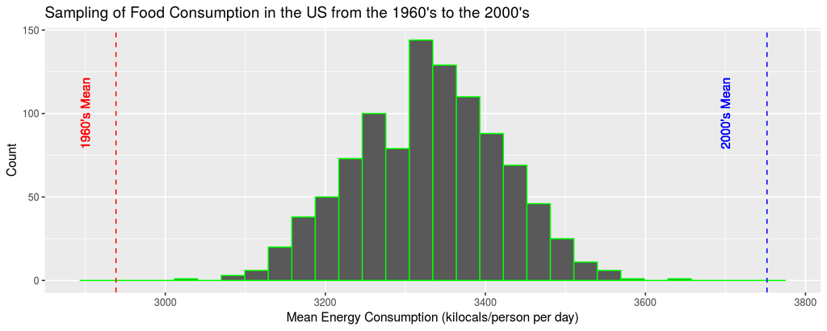

```r
#plot
ggplot(data=output) + geom_histogram(mapping=aes(values),color="green", bins=30) +
  geom_vline(aes(xintercept = m60),color="red",lty=2) +
  geom_vline(aes(xintercept = m2k),color="blue",lty=2) +
  geom_text(aes(x=3700, label="2000's Mean", y=100), colour="blue", angle=90, text=element_text(size=20)) +
  geom_text(aes(x=2900, label="1960's Mean", y=100), colour="red", angle=90, text=element_text(size=20)) +
  xlab("Mean Energy Consumption (kilocals/person per day)") +
  ylab("Count") +
  ggtitle("Sampling of Food Consumption in the US from the 1960's to the 2000's")
```

```r
#mean of the test stat 1K
MM <- sapply(output,mean)
#standard deviation of the test stat 1K
SS <- sapply(output,sd)

#zscore 60's
z60 <- (m60 - MM)/SS
#ascore 2k's
z2k <- (m2k - MM)/SS
```

The distribution of the test statistic is fairly normal with mean 3329.263917 and standard deviation 90.8308004. It is seen that the mean value for the 1960’s is 2938.41 and sits at the 0th percentile. This means that there are no values in the distribution of the test statistic that is lower than this mean. Furthermore, the z-score for an assumed normal distribution is -4.3030989 which tells us that there is a significant difference between average for the 60’s and testing average. Additionally, the same analysis is true for the value in the 2000’s. The average food consumption in the 2000’s is 3751.9375 which sits at the 100th percentile (technically 99.9th) and has a z-score of 4.6534169. By assessing these scores, the null hypothesis can be rejected and it can be said that there is a significant difference between food consumption in the 1960’s and in the 2000’s.

With regard to CU, this increase in consumption on average means two things for our school. First, the school must make sure they are promoting health programs in order to keep students active and not let them consume more food than they can maintain. Second, since there has been an increase in consumption, the school must keep funding research about food sustainability. With a growing population and growing consumption, research on sustatinable food would be a good investment for the future of society.

## Is there a difference in BMI? (Lindsay)

```r
fBMI<-gather(femaleBMI, -`Country`, key=year, value="femaleBMI")
BMI_f<-rename(fBMI, "country"="Country")
mBMI<-gather(maleBMI, -`Country`, key=year, value="maleBMI")
BMI_m<-rename(mBMI, "country"="Country")
addFBMI<-merge(gapminder, BMI_f, by=c("country"="country", "year"="year"))
BMI.data<-merge(addFBMI, BMI_m, by=c("country"="country", "year"="year"))
```

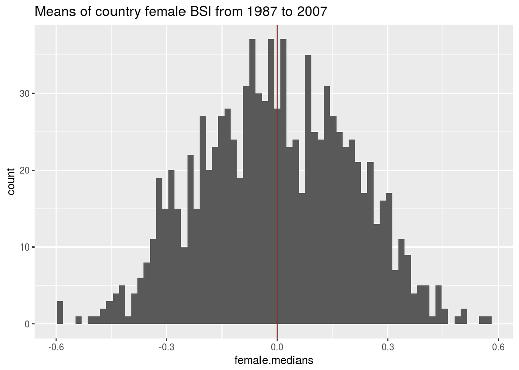

```
##        30%        70%
## -0.1214542  0.1204664
```

The above data illustrates that over time there as been little to no change in the Afrian populatin BMI. This suggests that the population has maintained a steady average BMI from 1987-2007, suggesting the overall health of the population has not changed. Using this model to represent a larger demographic, no change in BMI indicates a stability for population health, however, if recalculated and the BMI fuluctuates, it would indicate possible heath issues such as obesity, or malnutrition. To make this model more accurate, it would be benificial to determine the change in BMI for more recent dates and other countries.

## Is there a change in adults with HIV? (Lexie)

Analysing the relationship between adults with HIV and the GDP of a country is important for the student population because this will create an awareness for the student population that we can act on. HIV in developing countries will have to be treated differently than is it treated in the US due to the lack of resources, which can be fixed and addressed by our generation starting with creating awareness.

Question: How is GDP related to adults with HIV? This is important because it can affect how we address AIDS in developing countries compared to how we treat it in developed countries. Null Hypothesis: GDP is not related to the amount of adults with HIV.

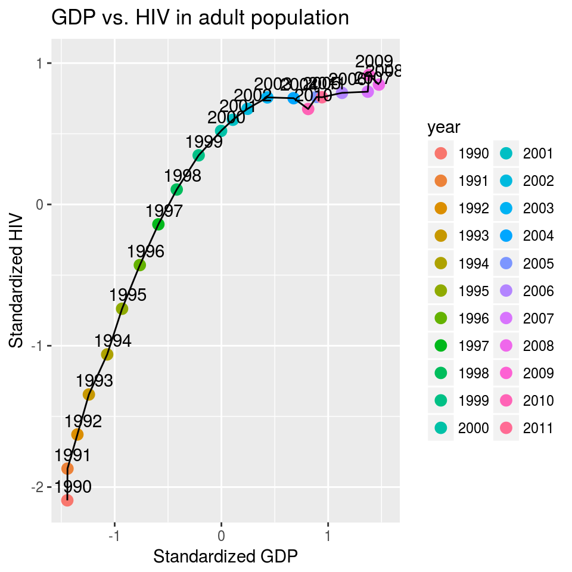

Test Statistic: Using the standardized values for a selected number of countries GDP and adults with HIV, the graph shows for some time between 1990-2011, the standardized number for GDP and HIV show a linear relationship. As time gets closer to 2000, the trend plateaus and remains slowly increasing for the rest of the plot. This shows us that there can be some relation between adults with HIV and the GDP of a country which proves my null hypothesis wrong.

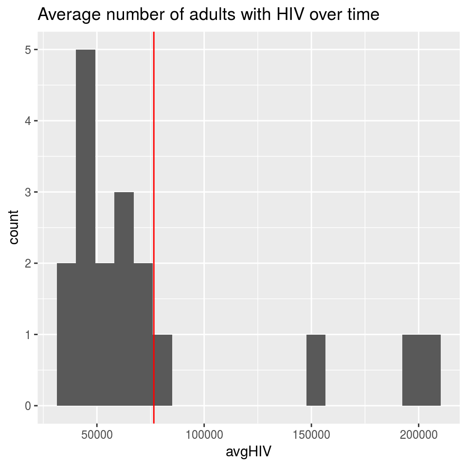

In this histogram, the distribution is mostly on the left side of the average, but still close to the median. This calculation is overall an accurate representation of the average number of adults with HIV over time.

## How does employment change from the 90’s to the 00’s? (Li)

The question is “Did the students (15-24 years old) have a better chance to get employed in the United States from the 1990’s to the 2000’s?”

The Null Hypothesis is “There is no change between the employment rate for young people in US between the 1990’s and the 2000’s”

The test statistic of the data is a mean of a sample of 10 values from the data.

```r
employment <- read_csv("https://github.com/bakerscott/CU-APPM2720/raw/master/m5/Lab13/indicator_t%2015-24%20employ.csv")

colnames(employment) <- c("country","1991","1992","1993","1994", "1995","1996","1997","1998","1999","2000","2001","2002","2003","2004","2005","2006","2007")

rate <- gather(employment, -'country', key = "year", value = "EmploymentRate")
rate$year <- as.numeric(rate$year)
rate$EmploymentRate <- as.numeric(rate$EmploymentRate)

Data <- filter(rate, country == "United States", (year < 2000 & year >= 1900) | (year < 2100 & year >= 2000))

Data90 <- filter(rate, country == "United States", (year < 2000 & year >= 1900))

Data00 <- filter(rate, country == "United States", (year < 2100 & year >= 2000))

i <- 0
j <- 0
n <- 1000

output <- as.data.frame(1:n)
colnames(output) <- c("values")

while(i < n){
  temp <- sample_n(Data,10,replace=TRUE)
  meanT <- mean(temp$EmploymentRate)
  output[i+1,1] <- meanT
  i <- i + 1
}


m90 <- mean(Data90$EmploymentRate)
m00 <- mean(Data00$EmploymentRate)
pm90 <- 0
pm00 <- 0


while(j < n){
  if(output[j+1,1] < m90){
    pm90 <- pm90 + 1
  }
  else if(output[j+1,1] < m00){
    pm00 <- pm00 + 1
  }
  j <- j + 1
}


pm90 <- pm90 / n*100
pm00 <- pm00 / n*100

pm90
```

```
## [1] 98.5
```

```r
pm00
```

```
## [1] 0
```

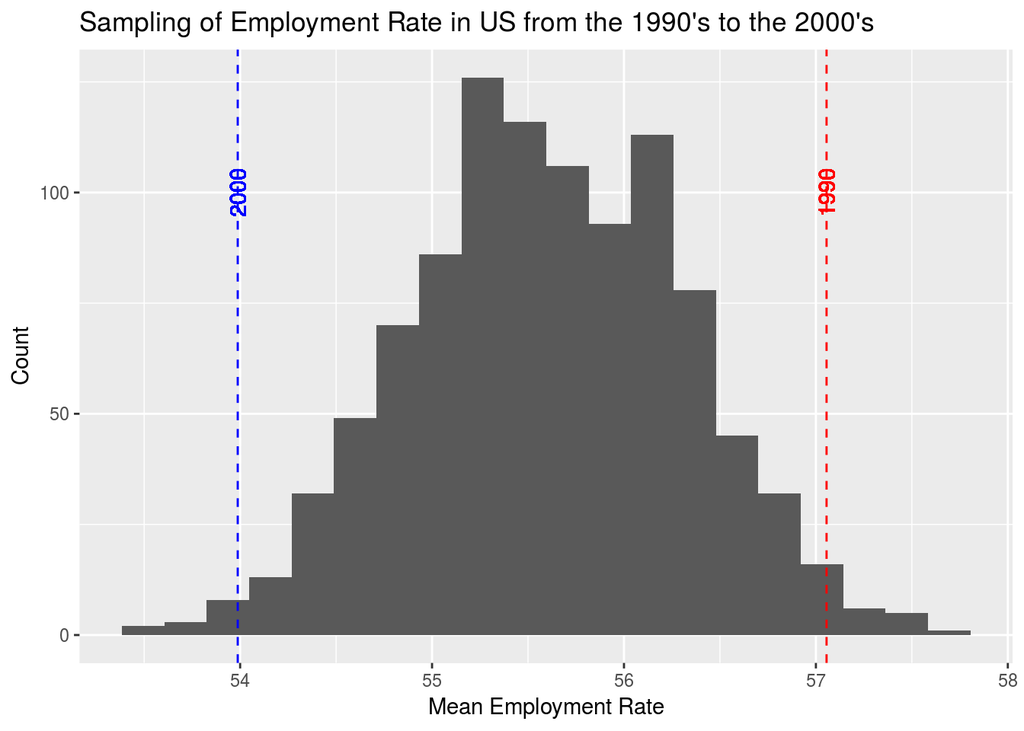

```r
ggplot(data=output) + geom_histogram(mapping=aes(values), bins=20) +
  geom_vline(aes(xintercept = m90),color="red",lty=2) +
  geom_vline(aes(xintercept = m00),color="blue",lty=2) +
  geom_text(aes(x=m00, label="2000", y=100), colour="blue", angle=90, text=element_text(size=16)) +
  geom_text(aes(x=m90, label="1990", y=100), colour="red", angle=90, text=element_text(size=16)) +
  xlab("Mean Employment Rate") +
  ylab("Count") +
  ggtitle("Sampling of Employment Rate in US from the 1990's to the 2000's")
```

In term of the Chancellor of CU Boulder’s request for help him and others around campus “benefit humanity”, we would encourage students to go to graduate school after graduating and for the students who would like to work. Also, we would suggest that the career service of CU should be cherished and developed with more investment in the future to help students to have a better chance to get a decent job.

# Contributions

- Lindsay: Created functions to find differences of values, then randomly select data to calculate the mean, then plotted values. Also merged datasets and found percentiles for data.
- Lexie: Analysed subquestion relating to adults with HIV in countries with varying GDP’s by merging and tidying 2 data sets from the gapminder website while using gapminder as well.
- Li: Used interating functions to testing the hypothesis about whether the employment rate of students between 1991 and 2007 is decreasing or increasing and related it with the overall question about CU.
- Scott: Wrote the introduction and the subquestion on food consumption. Responsible for knitting the final submission and managing file in the git.